# Workshop: Crítica e Imputação de Dados no R: preparação dos dados

Vitor Marinho

2023

# Introdução

Nesta oficina, aprenderemos como usar o pacote DataMaid no R para uma etapa prévia a crítica de dados: a preparação dos dados.

Documentação DataMaid : https://cran.r-project.org/web/packages/dataMaid/index.html

```r
vignette("extending_dataMaid")
```

```
## starting httpd help server ... done
```

Tutorial disponível: https://github.com/vitor-marinho-fjp/Critica_Datamaid

O que é o DataMaid?

Um assistente de limpeza de dados capaz de fornecer um documento para ser lido e avaliado por uma pessoa. Uma ferramenta para auxiliar na lógica/verificação de erros tanto em colunas quanto em linhas.

### Exemplos de erros em verificações de dados para a limpeza de dados:

- Classe incorreta
- Duplicatas
- Consistência de capitalização (**B**elo **H**orizonte vs **B**elo **h**orizonte)
- Valor improvável (peso = 1000, idade = 201)
- Espaços em branco
- Indicadores de falta não reconhecidos
- Quantidade de faltantes (NA)
- Observações/categorias únicas com contagem baixa
- Dados imprecisos (data de falecimento antes da data de nascimento)

### Inserção do dataMaid no Fluxo de trabalho em Ciência de Dados

Foco nos dois primeiros passos: Import → Tidy

# **Import/Tidy**

## Pacotes utilizados

```r
### Instalação e Carregamento do Pacote

# Lista de pacotes necessários
pacotes <- c('dataMaid', 'tidyverse', 'readxl', 'gtExtras')

# Verificar se os pacotes estão instalados e instalá-los se necessário
for (pacote in pacotes) {
  if (!requireNamespace(pacote, quietly = TRUE)) {
    install.packages(pacote)
    library(pacote, character.only = TRUE)
  } else {
    library(pacote, character.only = TRUE)
  }
}
```

Documentação:

## Carregando os Dados de Exemplo Indicadores de Saúde

Disponível em: [IMRS-SAÚDE](https://docs.google.com/spreadsheets/d/1e8eTy8gwlWFLV8zzEPEB56WR0TkJ5i1u/edit?usp=sharing&ouid=114631608050578367156&rtpof=true&sd=true)

```r
imrs_saude <- read_excel("dados_simulados.xlsx")

head(imrs_saude)
```

```
## # A tibble: 6 × 24
##     IBGE7 S_TXBRUTAMORT S_TXBRUTAMORT_t_1 S_TXBRUTAMORTPAD S_TXMOISQCOR45A59
##     <dbl>         <dbl>             <dbl>            <dbl>             <dbl>
## 1 3100104          6.63              7.49             5.27              68.0
## 2 3100203          6.90              6.69             5.55              41.1
## 3 3100302          6.97              6.55             5.41              56.2
## 4 3100401          7.22              7.36             5.46              40.0
## 5 3100500          6.13              5.83             4.72              59.4
## 6 3100609          4.98              5.43             4.33              34.6
## # ℹ 19 more variables: S_TXMOAVC45A59 <dbl>, S_TXMOATRA15A29 <dbl>,
## #   S_TXMOHOMI <dbl>, S_TXMOHOMI15A29 <dbl>, S_TXMOCANCOLUT <dbl>,
## #   S_TXMOCANMA <dbl>, S_TXMOCANPUL <dbl>, S_OBITO60 <dbl>,
## #   S_NASCBAIXOPESO <dbl>, S_OBINFSIFILS <dbl>, S_OBTETANONEO <dbl>,
## #   S_OBRAIVA <dbl>, S_INTERDVHID <dbl>, S_INTERDRSAI <dbl>, S_COBPSF <dbl>,
## #   S_NASC7CONSUL <dbl>, D_POPP0 <dbl>, D_POPT <dbl>, U_CONSSAU <chr>
```

## Análise Inicial dos Dados

A função `makeDataReport` produz um relatório de visão geral dos dados em que *resume* o conteúdo do conjunto de dados e *sinaliza possíveis problemas*. Esses potenciais erros são identificados executando um conjunto de *verificações de validação* específicas da classe, de modo que diferentes verificações sejam realizadas em diferentes tipos de variáveis. As etapas de verificação podem ser personalizadas de acordo com a entrada do usuário e/ou tipo de dados da variável inserida

Para cada variável, um conjunto de funções de pré-verificação (controladas pelo argumento preChecks) é executado primeiro e depois uma bateria de funções é aplicada dependendo da classe da variável.

# Extra: Personalizando o Report

Além da análise inicial, você pode criar regras personalizadas para a análise inicial dos dados.

Por exemplo, podemos verificar a variável *S_TXBRUTAMORT*

Trace a distribuição de uma variável.

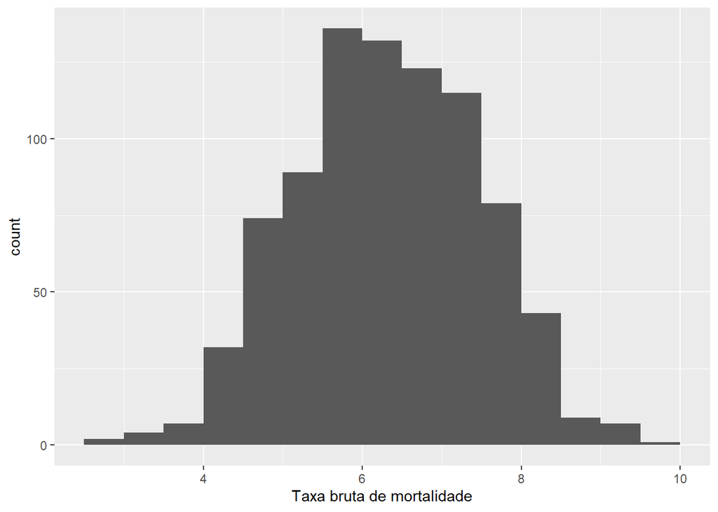

```r
standardVisual(imrs_saude$S_TXBRUTAMORT, "Taxa bruta de mortalidade")
```

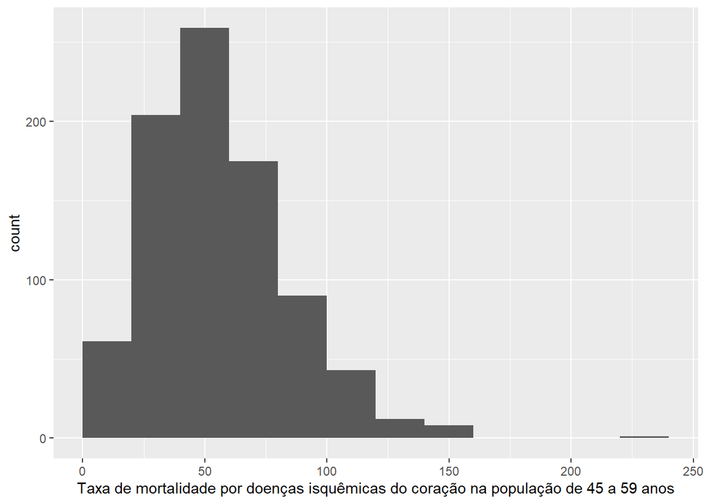

```r
standardVisual(imrs_saude$S_TXMOISQCOR45A59, "Taxa de mortalidade por doenças isquêmicas do coração na população de 45 a 59 anos")
```

## Trabalhando com funções personalizadas

### Funções de sumarização

Pode-se criar funções que seja do interesse a verificação. Por exemplo, um função para ocorrências de valores iguais a zero: `countZeros()`

Criando a função:

```r
countZeros <- function(v, ...) {
  val <- length(which(v == 0))
  summaryResult(list(feature = "No. zeros", result = val, value = val))
}
```

```r
countZeros(imrs_saude$S_TXMOHOMI15A29)
```

```
## No. zeros: 57
```

uma outra função útil seria a contagem dos valores atípicos (outliers) em uma variável numérica `v` usando a abordagem do intervalo interquartil (IQR) com um fator de limiar (threshold):

```r
#Função para Identificar Outliers:
countOutliers <- function(v, threshold = 1.5) {
  q1 <- quantile(v, 0.25)
  q3 <- quantile(v, 0.75)
  iqr <- q3 - q1
  lower_bound <- q1 - threshold * iqr
  upper_bound <- q3 + threshold * iqr
  val <- length(which(v < lower_bound | v > upper_bound))
  summaryResult(list(feature = "No. outliers", result = val, value = val))
}
```

Além dessas, outras possibilidades são possíveis, por exemplo, criar uma função que calcule estatísticas (média, mediana, etc.) para uma variável numérica, segmentadas por grupos de uma variável categórica. Isso pode ser útil para entender as diferenças entre grupos:

```r
calculateStatsByGroup <- function(data, numeric_var, categorical_var) {
  stats_by_group <- data %>%
    group_by({{categorical_var}}) %>%
    summarise(
      Mean = mean({{numeric_var}}, na.rm = TRUE),
      Median = median({{numeric_var}}, na.rm = TRUE),
      SD = sd({{numeric_var}}, na.rm = TRUE)
    )
  summaryResult(list(
    feature = paste("Summary Statistics by", as_label(categorical_var)),
    result = stats_by_group,
    value = NULL
  ))
}
```

### Adicionando novas funções ao `report`

A inclusão das funções criadas anteriormente são realizadas da seguinte maneira:

```r
makeDataReport(imrs_saude, summaries = setSummaries(
  character = defaultCharacterSummaries(add = c("countZeros", "countOutliers")),
  factor = defaultFactorSummaries(add = c("countZeros", "countOutliers")),
  labelled = defaultLabelledSummaries(add = c("countZeros", "countOutliers")),
  numeric = defaultNumericSummaries(add = c("countZeros", "countOutliers")),
  integer = defaultIntegerSummaries(add = c("countZeros", "countOutliers")),
  logical = defaultLogicalSummaries(add = c("countZeros", "countOutliers"))
), replace = TRUE, output = "html")
```

[output not shown]

[output not shown]

```
## Data report generation is finished. Please wait while your output file is being rendered.
```

**Funções do DataMaid**

| name | descrição |
| --- | --- |
| identifyCaseIssues | Identificar problemas |
| identifyLoners | Identificar variáveis com < 6 obs. |
| identifyMissing | Identificar valores ausentes mal codificados |
| identifyNums | Identificar variáveis numéricas ou inteiras classificadas incorretamente |
| identifyOutliers | Identificar outliers |
| identifyOutliersTBStyle | Identify outliers (Turkish Boxplot style) |
| identifyWhitespace | Identifique espaços em branco prefixados e sufixados |
| isCPR | Identify Danish CPR numbers |
| isEmpty | Verifique se a variável contém apenas um único valor |
| isKey | Verifique se a variável é uma chave |
| isSingular | Verifique se a variável contém apenas um único valor |
| isSupported | Verifique se a classe da variável é suportada pelo dataMaid. |

## Recursos Adicionais

Documentação DataMaid - https://github.com/ekstroem/DataMaid